# -------------INDEX OF THE SOLUTION---------------

# C. MACHINE LEARNING OBJECTIVE

# 1. READING DATASET

- ### -> 1.1. Data Description
- ### -> 1.2. Renaming Columns for better readability.

# 2. EXPLORATORY DATA ANALYSIS

- ### -> 2.1. Checking whether the data is balanced or not¶
- ### -> 2.1. Descriptive Stats
- ### -> 2.1. Structure of the data

# 3. DATA PREPROCESSING

- ### -> 3.1. Missing/NaN value check
- ### -> 3.2. NAN Value Imputation with Backward Fill (bfill) method.
- ### -> 3.3. Converting PERFORM_CNS_SCORE_DESCRIPTION into Multiple Categories
- ### -> 3.4. Understanding all the Distinct Values of our features
- ### -> 3.5. Converting CREDIT HISTORY LEN and AVG ACCOUNT AGE into Numeric Format
- ### -> 3.6. CONVERTING THE DATE OF BIRTH TO AGE AND DISBURSALDATE TO LOAN_AGE

# 4. SPLITTING THE DATASET INTO TRAIN-TEST (70-30)

# 5. FEATURE SELECTION

- ### -> 5.1. Identifying Useless Features and dropping them.
- ### -> 5.2. Listing the Numerical and Categorical Type Features.

# 6. SELECTING THE TOP NUMERICAL FEATURES using SelectKBest (Annona)

# 7. STANDARDIZING THE TRAIN AND TEST DATA

# 8. ENCODING THE CATEGORICAL VARIABLE USING ONE HOT ENCODER

# 9. SELECTING THE TOP CATEGORICAL FEATURES

# 10. MERGING THE NUMERICAL AND CATEGORICAL PROCESSSED FEATURES

# 11. CORELATION MATRIX

# 12. MODEL IMPLEMENTATION

- ### -> 12.1. RANDOM MODEL as Benchmark.
- ### -> 12.2. Logistic Regression with hyperparameter tuning.
- ### -> 12.Creating Objects of the MODELS
- ### -> 12.DATASET Balancing using Classifier Parameter
- ### -> 12.3. Logistic Regression
- ### -> 12.4. DECISION TREE
- ### -> 12.5. KNN
- ### -> 12.6. BAGGING: RANDOM FOREST CLASSIFIER
- ### -> 12.7. BOOSTING: XGBOOST with Hyperparameter Tuning (scale_pos_weight) Parameter.
- ### ->-> 12.7.1. XGBoost with scale_pos_weight=3
- ### ->-> 12.7.2. XGBoost with scale_pos_weight=2

# 13. COMPARISION

# 14. CONCLUSION

# -----------------------------------------------------------------------------------------------------------------

# A. DATA INFORMATION

Financial institutions incur significant losses due to the default of vehicle loans. This has led to the tightening up of vehicle loan underwriting and increased vehicle loan rejection rates. The need for a better credit risk scoring model is also raised by these institutions. This warrants a study to estimate the determinants of vehicle loan default. A financial institution has hired you to accurately predict the probability of loanee/borrower defaulting on a vehicle loan in the first EMI (Equated Monthly Instalments) on the due date. Following Information regarding the loan and loanee are provided in the datasets:

Loanee Information (Demographic data like age, Identity proof etc.)

Loan Information (Disbursal details, loan to value ratio etc.)

Bureau data & history (Bureau score, number of active accounts, the status of other loans, credit history etc.)

Doing so will ensure that clients capable of repayment are not rejected and important determinants can be identified which can be further used for minimising the default rates.

# B.BUSINESS OBJECTIVE

- ## To accurately predict the loanee/borrower defaulting or non defaulting on a vehicle loan in the first EMI (Equated Monthly Instalments) on the due date.

# C. MACHINE LEARNING OBJECTIVE

- ## 1. To build a high accuracy model for the Binary Classification of Defaulter or Non Defaulter.
- ## 2. To have good AUC Value.

# Importing Libraries

```python
import os
import re
import gc
from tqdm import tqdm
from datetime import date     #calculating age
from datetime import datetime #converting string to date
import matplotlib.pyplot as plt
import seaborn as sns
import numpy as np # linear algebra
import pandas as pd # data processing, CSV file I/O (e.g. pd.read_csv)
from sklearn.model_selection import GridSearchCV , train_test_split
from sklearn.model_selection import train_test_split
from sklearn.model_selection import train_test_split,KFold,cross_val_score
from sklearn.linear_model import LogisticRegression
from sklearn.metrics import accuracy_score , f1_score , make_scorer
from sklearn.preprocessing import StandardScaler,OneHotEncoder , LabelEncoder ,normalize
from sklearn.feature_selection import SelectKBest,f_classif,chi2
from sklearn.metrics.classification import accuracy_score, log_loss
from sklearn.metrics import confusion_matrix
from sklearn.linear_model import SGDClassifier
from sklearn.calibration import CalibratedClassifierCV
import matplotlib.pyplot as plt
from imblearn.over_sampling import SMOTE
from matplotlib.pyplot import figure
print("DONE")
```

```
DONE
```

# 1. READING DATASET

```python
dd1=pd.read_csv("../input/lt-vehicle-loan-default-prediction/train.csv")
```

```python
print("Total Size of the Provided Data: ",dd1.shape)
```

```
Total Size of the Provided Data:  (233154, 41)
```

```python
print("Provided Features: ",dd1.shape[1])
```

```
Provided Features:  41
```

## > 1.1. Data Description

```python
#Lets looks at data description
info = pd.read_csv("../input/lt-vehicle-loan-default-prediction/data_dictionary.csv")
info
```

|  | Unnamed: 0 | Variable Name | Description | Unnamed: 2 |
| --- | --- | --- | --- | --- |
| 0 | 0 | UniqueID | Identifier for customers | NaN |
| 1 | 1 | loan_default | Payment default in the first EMI on due date | NaN |
| 2 | 2 | disbursed_amount | Amount of Loan disbursed | NaN |
| 3 | 3 | asset_cost | Cost of the Asset | NaN |
| 4 | 4 | ltv | Loan to Value of the asset | NaN |
| 5 | 5 | branch_id | Branch where the loan was disbursed | NaN |
| 6 | 6 | supplier_id | Vehicle Dealer where the loan was disbursed | NaN |
| 7 | 7 | manufacturer_id | Vehicle manufacturer(Hero, Honda, TVS etc.) | NaN |
| 8 | 8 | Current_pincode | Current pincode of the customer | NaN |
| 9 | 9 | Date.of.Birth | Date of birth of the customer | NaN |
| 10 | 10 | Employment.Type | Employment Type of the customer (Salaried/Self... | NaN |
| 11 | 11 | DisbursalDate | Date of disbursement | NaN |
| 12 | 12 | State_ID | State of disbursement | NaN |
| 13 | 13 | Employee_code_ID | Employee of the organization who logged the di... | NaN |
| 14 | 14 | MobileNo_Avl_Flag | if Mobile no. was shared by the customer then ... | NaN |
| 15 | 15 | Aadhar_flag | if aadhar was shared by the customer then flag... | NaN |
| 16 | 16 | PAN_flag | if pan was shared by the customer then flagged... | NaN |
| 17 | 17 | VoterID_flag | if voter was shared by the customer then flag... | NaN |
| 18 | 18 | Driving_flag | if DL was shared by the customer then flagged ... | NaN |
| 19 | 19 | Passport_flag | if passport was shared by the customer then fl... | NaN |
| 20 | 20 | PERFORM_CNS.SCORE | Bureau Score | NaN |
| 21 | 21 | PERFORM_CNS.SCORE.DESCRIPTION | Bureau score description | NaN |
| 22 | 22 | PRI.NO.OF.ACCTS | count of total loans taken by the customer at ... | Primary accounts are those which the customer ... |
| 23 | 23 | PRI.ACTIVE.ACCTS | count of active loans taken by the customer at... | NaN |
| 24 | 24 | PRI.OVERDUE.ACCTS | count of default accounts at the time of disbu... | NaN |
| 25 | 25 | PRI.CURRENT.BALANCE | total Principal outstanding amount of the acti... | NaN |
| 26 | 26 | PRI.SANCTIONED.AMOUNT | total amount that was sanctioned for all the l... | NaN |
| 27 | 27 | PRI.DISBURSED.AMOUNT | total amount that was disbursed for all the lo... | NaN |
| 28 | 28 | SEC.NO.OF.ACCTS | count of total loans taken by the customer at ... | Secondary accounts are those which the custome... |
| 29 | 29 | SEC.ACTIVE.ACCTS | count of active loans taken by the customer at... | NaN |
| 30 | 30 | SEC.OVERDUE.ACCTS | count of default accounts at the time of disbu... | NaN |
| 31 | 31 | SEC.CURRENT.BALANCE | total Principal outstanding amount of the acti... | NaN |
| 32 | 32 | SEC.SANCTIONED.AMOUNT | total amount that was sanctioned for all the l... | NaN |
| 33 | 33 | SEC.DISBURSED.AMOUNT | total amount that was disbursed for all the lo... | NaN |
| 34 | 34 | PRIMARY.INSTAL.AMT | EMI Amount of the primary loan | NaN |
| 35 | 35 | SEC.INSTAL.AMT | EMI Amount of the secondary loan | NaN |
| 36 | 36 | NEW.ACCTS.IN.LAST.SIX.MONTHS | New loans taken by the customer in last 6 mont... | NaN |
| 37 | 37 | DELINQUENT.ACCTS.IN.LAST.SIX.MONTHS | Loans defaulted in the last 6 months | NaN |
| 38 | 38 | AVERAGE.ACCT.AGE | Average loan tenure | NaN |
| 39 | 39 | CREDIT.HISTORY.LENGTH | Time since first loan | NaN |
| 40 | 40 | NO.OF_INQUIRIES | Enquries done by the customer for loans | NaN |

## -> 1.2. Renaming Columns for better readability.

```python
# CHANGING TO UPPER CASE
dd1.columns=dd1.columns.str.upper()
# REPLACING "." with "_" in column names
dd1.columns=dd1.columns.str.replace(".","_")
```

```python
dd1.head()
```

|  | UNIQUEID | DISBURSED_AMOUNT | ASSET_COST | LTV | BRANCH_ID | SUPPLIER_ID | MANUFACTURER_ID | CURRENT_PINCODE_ID | DATE_OF_BIRTH | EMPLOYMENT_TYPE | ... | SEC_SANCTIONED_AMOUNT | SEC_DISBURSED_AMOUNT | PRIMARY_INSTAL_AMT | SEC_INSTAL_AMT | NEW_ACCTS_IN_LAST_SIX_MONTHS | DELINQUENT_ACCTS_IN_LAST_SIX_MONTHS | AVERAGE_ACCT_AGE | CREDIT_HISTORY_LENGTH | NO_OF_INQUIRIES | LOAN_DEFAULT |
| --- | --- | --- | --- | --- | --- | --- | --- | --- | --- | --- | --- | --- | --- | --- | --- | --- | --- | --- | --- | --- | --- |
| 0 | 420825 | 50578 | 58400 | 89.55 | 67 | 22807 | 45 | 1441 | 01-01-84 | Salaried | ... | 0 | 0 | 0 | 0 | 0 | 0 | 0yrs 0mon | 0yrs 0mon | 0 | 0 |
| 1 | 537409 | 47145 | 65550 | 73.23 | 67 | 22807 | 45 | 1502 | 31-07-85 | Self employed | ... | 0 | 0 | 1991 | 0 | 0 | 1 | 1yrs 11mon | 1yrs 11mon | 0 | 1 |
| 2 | 417566 | 53278 | 61360 | 89.63 | 67 | 22807 | 45 | 1497 | 24-08-85 | Self employed | ... | 0 | 0 | 0 | 0 | 0 | 0 | 0yrs 0mon | 0yrs 0mon | 0 | 0 |
| 3 | 624493 | 57513 | 66113 | 88.48 | 67 | 22807 | 45 | 1501 | 30-12-93 | Self employed | ... | 0 | 0 | 31 | 0 | 0 | 0 | 0yrs 8mon | 1yrs 3mon | 1 | 1 |
| 4 | 539055 | 52378 | 60300 | 88.39 | 67 | 22807 | 45 | 1495 | 09-12-77 | Self employed | ... | 0 | 0 | 0 | 0 | 0 | 0 | 0yrs 0mon | 0yrs 0mon | 1 | 1 |

5 rows × 41 columns

# 2. EXPLORATORY DATA ANALYSIS

```python
dd1.head()
```

|  | UNIQUEID | DISBURSED_AMOUNT | ASSET_COST | LTV | BRANCH_ID | SUPPLIER_ID | MANUFACTURER_ID | CURRENT_PINCODE_ID | DATE_OF_BIRTH | EMPLOYMENT_TYPE | ... | SEC_SANCTIONED_AMOUNT | SEC_DISBURSED_AMOUNT | PRIMARY_INSTAL_AMT | SEC_INSTAL_AMT | NEW_ACCTS_IN_LAST_SIX_MONTHS | DELINQUENT_ACCTS_IN_LAST_SIX_MONTHS | AVERAGE_ACCT_AGE | CREDIT_HISTORY_LENGTH | NO_OF_INQUIRIES | LOAN_DEFAULT |
| --- | --- | --- | --- | --- | --- | --- | --- | --- | --- | --- | --- | --- | --- | --- | --- | --- | --- | --- | --- | --- | --- |
| 0 | 420825 | 50578 | 58400 | 89.55 | 67 | 22807 | 45 | 1441 | 01-01-84 | Salaried | ... | 0 | 0 | 0 | 0 | 0 | 0 | 0yrs 0mon | 0yrs 0mon | 0 | 0 |
| 1 | 537409 | 47145 | 65550 | 73.23 | 67 | 22807 | 45 | 1502 | 31-07-85 | Self employed | ... | 0 | 0 | 1991 | 0 | 0 | 1 | 1yrs 11mon | 1yrs 11mon | 0 | 1 |
| 2 | 417566 | 53278 | 61360 | 89.63 | 67 | 22807 | 45 | 1497 | 24-08-85 | Self employed | ... | 0 | 0 | 0 | 0 | 0 | 0 | 0yrs 0mon | 0yrs 0mon | 0 | 0 |
| 3 | 624493 | 57513 | 66113 | 88.48 | 67 | 22807 | 45 | 1501 | 30-12-93 | Self employed | ... | 0 | 0 | 31 | 0 | 0 | 0 | 0yrs 8mon | 1yrs 3mon | 1 | 1 |
| 4 | 539055 | 52378 | 60300 | 88.39 | 67 | 22807 | 45 | 1495 | 09-12-77 | Self employed | ... | 0 | 0 | 0 | 0 | 0 | 0 | 0yrs 0mon | 0yrs 0mon | 1 | 1 |

5 rows × 41 columns

```python
dd1.columns
```

```
Index(['UNIQUEID', 'DISBURSED_AMOUNT', 'ASSET_COST', 'LTV', 'BRANCH_ID',
       'SUPPLIER_ID', 'MANUFACTURER_ID', 'CURRENT_PINCODE_ID', 'DATE_OF_BIRTH',
       'EMPLOYMENT_TYPE', 'DISBURSALDATE', 'STATE_ID', 'EMPLOYEE_CODE_ID',
       'MOBILENO_AVL_FLAG', 'AADHAR_FLAG', 'PAN_FLAG', 'VOTERID_FLAG',
       'DRIVING_FLAG', 'PASSPORT_FLAG', 'PERFORM_CNS_SCORE',
       'PERFORM_CNS_SCORE_DESCRIPTION', 'PRI_NO_OF_ACCTS', 'PRI_ACTIVE_ACCTS',
       'PRI_OVERDUE_ACCTS', 'PRI_CURRENT_BALANCE', 'PRI_SANCTIONED_AMOUNT',
       'PRI_DISBURSED_AMOUNT', 'SEC_NO_OF_ACCTS', 'SEC_ACTIVE_ACCTS',
       'SEC_OVERDUE_ACCTS', 'SEC_CURRENT_BALANCE', 'SEC_SANCTIONED_AMOUNT',
       'SEC_DISBURSED_AMOUNT', 'PRIMARY_INSTAL_AMT', 'SEC_INSTAL_AMT',
       'NEW_ACCTS_IN_LAST_SIX_MONTHS', 'DELINQUENT_ACCTS_IN_LAST_SIX_MONTHS',
       'AVERAGE_ACCT_AGE', 'CREDIT_HISTORY_LENGTH', 'NO_OF_INQUIRIES',
       'LOAN_DEFAULT'],
      dtype='object')
```

## -> 2.1. Checking whether the data is balanced or not¶

```python
dd1['LOAN_DEFAULT'].value_counts()
```

```
0    182543
1     50611
Name: LOAN_DEFAULT, dtype: int64
```

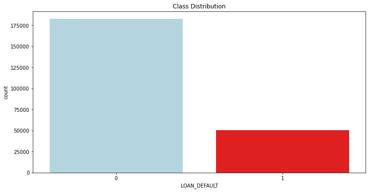

```python
#Graph
my_pal = {0: 'lightblue', 1: 'red'}

plt.figure(figsize = (12, 6))
ax = sns.countplot(x = 'LOAN_DEFAULT', data = dd1, palette = my_pal)
plt.title('Class Distribution')
plt.show()
```

### **OBSERVATION:** Data is higly imbalanced

### **ACTION:** Data need to made BALANCED either using SMOTE or using Classfier's class_weight='balanced' technique.

## -> 2.2. Descriptive Stats

```python
dd1.describe()
```

|  | UNIQUEID | DISBURSED_AMOUNT | ASSET_COST | LTV | BRANCH_ID | SUPPLIER_ID | MANUFACTURER_ID | CURRENT_PINCODE_ID | STATE_ID | EMPLOYEE_CODE_ID | ... | SEC_OVERDUE_ACCTS | SEC_CURRENT_BALANCE | SEC_SANCTIONED_AMOUNT | SEC_DISBURSED_AMOUNT | PRIMARY_INSTAL_AMT | SEC_INSTAL_AMT | NEW_ACCTS_IN_LAST_SIX_MONTHS | DELINQUENT_ACCTS_IN_LAST_SIX_MONTHS | NO_OF_INQUIRIES | LOAN_DEFAULT |
| --- | --- | --- | --- | --- | --- | --- | --- | --- | --- | --- | --- | --- | --- | --- | --- | --- | --- | --- | --- | --- | --- |
| count | 233154.000000 | 233154.000000 | 2.331540e+05 | 233154.000000 | 233154.000000 | 233154.000000 | 233154.000000 | 233154.000000 | 233154.000000 | 233154.000000 | ... | 233154.000000 | 2.331540e+05 | 2.331540e+05 | 2.331540e+05 | 2.331540e+05 | 2.331540e+05 | 233154.000000 | 233154.000000 | 233154.000000 | 233154.000000 |
| mean | 535917.573376 | 54356.993528 | 7.586507e+04 | 74.746530 | 72.936094 | 19638.635035 | 69.028054 | 3396.880247 | 7.262243 | 1549.477148 | ... | 0.007244 | 5.427793e+03 | 7.295923e+03 | 7.179998e+03 | 1.310548e+04 | 3.232684e+02 | 0.381833 | 0.097481 | 0.206615 | 0.217071 |
| std | 68315.693711 | 12971.314171 | 1.894478e+04 | 11.456636 | 69.834995 | 3491.949566 | 22.141304 | 2238.147502 | 4.482230 | 975.261278 | ... | 0.111079 | 1.702370e+05 | 1.831560e+05 | 1.825925e+05 | 1.513679e+05 | 1.555369e+04 | 0.955107 | 0.384439 | 0.706498 | 0.412252 |
| min | 417428.000000 | 13320.000000 | 3.700000e+04 | 10.030000 | 1.000000 | 10524.000000 | 45.000000 | 1.000000 | 1.000000 | 1.000000 | ... | 0.000000 | -5.746470e+05 | 0.000000e+00 | 0.000000e+00 | 0.000000e+00 | 0.000000e+00 | 0.000000 | 0.000000 | 0.000000 | 0.000000 |
| 25% | 476786.250000 | 47145.000000 | 6.571700e+04 | 68.880000 | 14.000000 | 16535.000000 | 48.000000 | 1511.000000 | 4.000000 | 713.000000 | ... | 0.000000 | 0.000000e+00 | 0.000000e+00 | 0.000000e+00 | 0.000000e+00 | 0.000000e+00 | 0.000000 | 0.000000 | 0.000000 | 0.000000 |
| 50% | 535978.500000 | 53803.000000 | 7.094600e+04 | 76.800000 | 61.000000 | 20333.000000 | 86.000000 | 2970.000000 | 6.000000 | 1451.000000 | ... | 0.000000 | 0.000000e+00 | 0.000000e+00 | 0.000000e+00 | 0.000000e+00 | 0.000000e+00 | 0.000000 | 0.000000 | 0.000000 | 0.000000 |
| 75% | 595039.750000 | 60413.000000 | 7.920175e+04 | 83.670000 | 130.000000 | 23000.000000 | 86.000000 | 5677.000000 | 10.000000 | 2362.000000 | ... | 0.000000 | 0.000000e+00 | 0.000000e+00 | 0.000000e+00 | 1.999000e+03 | 0.000000e+00 | 0.000000 | 0.000000 | 0.000000 | 0.000000 |
| max | 671084.000000 | 990572.000000 | 1.628992e+06 | 95.000000 | 261.000000 | 24803.000000 | 156.000000 | 7345.000000 | 22.000000 | 3795.000000 | ... | 8.000000 | 3.603285e+07 | 3.000000e+07 | 3.000000e+07 | 2.564281e+07 | 4.170901e+06 | 35.000000 | 20.000000 | 36.000000 | 1.000000 |

8 rows × 35 columns

## -> 2.3. Structure of the data

```python
dd1.info()
```

```
<class 'pandas.core.frame.DataFrame'>
RangeIndex: 233154 entries, 0 to 233153
Data columns (total 41 columns):
 #   Column                               Non-Null Count   Dtype
---  ------                               --------------   -----
 0   UNIQUEID                             233154 non-null  int64
 1   DISBURSED_AMOUNT                     233154 non-null  int64
 2   ASSET_COST                           233154 non-null  int64
 3   LTV                                  233154 non-null  float64
 4   BRANCH_ID                            233154 non-null  int64
 5   SUPPLIER_ID                          233154 non-null  int64
 6   MANUFACTURER_ID                      233154 non-null  int64
 7   CURRENT_PINCODE_ID                   233154 non-null  int64
 8   DATE_OF_BIRTH                        233154 non-null  object
 9   EMPLOYMENT_TYPE                      225493 non-null  object
```

[output cut: 33 more lines]

### **OBSERVATION:**

1. We need to change the date and time related variables (DATE_OF_BIRTH, DISBURSALDATE,AVERAGE_ACCT_AGE).</br>
2. EMPLOYMENT_TYPE has less data, we need to analyse it further.</br>
3. The beauruea data history is given under the variable PERFORM_CNS.SCORE.DESCRIPTION with 20 distinct classes we need to figure out a way to encode it such that its acceptable to our model

# 3. DATA PREPROCESSING

## -> 3.1. Missing value check

```python
dd1.isnull().sum()
```

```
UNIQUEID                                  0
DISBURSED_AMOUNT                          0
ASSET_COST                                0
LTV                                       0
BRANCH_ID                                 0
SUPPLIER_ID                               0
MANUFACTURER_ID                           0
CURRENT_PINCODE_ID                        0
DATE_OF_BIRTH                             0
EMPLOYMENT_TYPE                        7661
DISBURSALDATE                             0
STATE_ID                                  0
EMPLOYEE_CODE_ID                          0
MOBILENO_AVL_FLAG                         0
AADHAR_FLAG                               0
PAN_FLAG                                  0
VOTERID_FLAG                              0
DRIVING_FLAG                              0
PASSPORT_FLAG                             0
PERFORM_CNS_SCORE                         0
PERFORM_CNS_SCORE_DESCRIPTION             0
PRI_NO_OF_ACCTS                           0
PRI_ACTIVE_ACCTS                          0
PRI_OVERDUE_ACCTS                         0
PRI_CURRENT_BALANCE                       0
PRI_SANCTIONED_AMOUNT                     0
PRI_DISBURSED_AMOUNT                      0
SEC_NO_OF_ACCTS                           0
SEC_ACTIVE_ACCTS                          0
SEC_OVERDUE_ACCTS                         0
SEC_CURRENT_BALANCE                       0
SEC_SANCTIONED_AMOUNT                     0
SEC_DISBURSED_AMOUNT                      0
PRIMARY_INSTAL_AMT                        0
SEC_INSTAL_AMT                            0
NEW_ACCTS_IN_LAST_SIX_MONTHS              0
DELINQUENT_ACCTS_IN_LAST_SIX_MONTHS       0
AVERAGE_ACCT_AGE                          0
CREDIT_HISTORY_LENGTH                     0
NO_OF_INQUIRIES                           0
LOAN_DEFAULT                              0
dtype: int64
```

### **OBSERVATION:** EMPLOYMENT_TYPE column has 7661 NaN Values which needs to be handled

## -> 3.2. NaN Value Imputation with Backward Fill (bfill) method.

```python
dd1['EMPLOYMENT_TYPE'].unique()
```

```
array(['Salaried', 'Self employed', nan], dtype=object)
```

```python
## TOTAL NULL VALUES
dd1['EMPLOYMENT_TYPE'].isna().sum()
```

```
7661
```

```python
dd1['EMPLOYMENT_TYPE'].value_counts()
```

```
Self employed    127635
Salaried          97858
Name: EMPLOYMENT_TYPE, dtype: int64
```

### We have missing values only in the variable "EMPLOYMENT_TYPE" which we will impute it using the backward fill method

```python
dd1['EMPLOYMENT_TYPE'] = dd1['EMPLOYMENT_TYPE'].fillna(method = 'bfill')
```

```python
dd1['EMPLOYMENT_TYPE'].unique()
```

```
array(['Salaried', 'Self employed'], dtype=object)
```

```python
dd1['EMPLOYMENT_TYPE'].isna().sum()
```

```
0
```

```python
dd1['EMPLOYMENT_TYPE'].value_counts()
```

```
Self employed    132002
Salaried         101152
Name: EMPLOYMENT_TYPE, dtype: int64
```

```python
dd1.nunique()
```

```
UNIQUEID                               233154
DISBURSED_AMOUNT                        24565
ASSET_COST                              46252
LTV                                      6579
BRANCH_ID                                  82
SUPPLIER_ID                              2953
MANUFACTURER_ID                            11
CURRENT_PINCODE_ID                       6698
DATE_OF_BIRTH                           15433
EMPLOYMENT_TYPE                             2
DISBURSALDATE                              84
STATE_ID                                   22
EMPLOYEE_CODE_ID                         3270
MOBILENO_AVL_FLAG                           1
AADHAR_FLAG                                 2
PAN_FLAG                                    2
VOTERID_FLAG                                2
DRIVING_FLAG                                2
PASSPORT_FLAG                               2
PERFORM_CNS_SCORE                         573
PERFORM_CNS_SCORE_DESCRIPTION              20
PRI_NO_OF_ACCTS                           108
PRI_ACTIVE_ACCTS                           40
PRI_OVERDUE_ACCTS                          22
PRI_CURRENT_BALANCE                     71341
PRI_SANCTIONED_AMOUNT                   44390
PRI_DISBURSED_AMOUNT                    47909
SEC_NO_OF_ACCTS                            37
SEC_ACTIVE_ACCTS                           23
SEC_OVERDUE_ACCTS                           9
SEC_CURRENT_BALANCE                      3246
SEC_SANCTIONED_AMOUNT                    2223
SEC_DISBURSED_AMOUNT                     2553
PRIMARY_INSTAL_AMT                      28067
SEC_INSTAL_AMT                           1918
NEW_ACCTS_IN_LAST_SIX_MONTHS               26
DELINQUENT_ACCTS_IN_LAST_SIX_MONTHS        14
AVERAGE_ACCT_AGE                          192
CREDIT_HISTORY_LENGTH                     294
NO_OF_INQUIRIES                            25
LOAN_DEFAULT                                2
dtype: int64
```

### **OBSERVATION:**

- ### 1. From the above information we can say that the variable MOBILENO_AVL_FLAG has only 1 class hence we can drop that variable as is not going to provide any unique information to our model.
- ### 1. PERFORM_CNS_SCORE_DESCRIPTION seems important, need to be handled as it related to the CNS SCORE.

```python
dd1['PERFORM_CNS_SCORE_DESCRIPTION'].nunique()
```

```
20
```

```python
dd1['PERFORM_CNS_SCORE_DESCRIPTION'].unique()
```

```
array(['No Bureau History Available', 'I-Medium Risk', 'L-Very High Risk',
       'A-Very Low Risk',
       'Not Scored: Not Enough Info available on the customer',
       'D-Very Low Risk', 'M-Very High Risk', 'B-Very Low Risk',
       'C-Very Low Risk', 'E-Low Risk', 'H-Medium Risk', 'F-Low Risk',
       'K-High Risk',
       'Not Scored: No Activity seen on the customer (Inactive)',
       'Not Scored: Sufficient History Not Available',
       'Not Scored: No Updates available in last 36 months', 'G-Low Risk',
       'J-High Risk', 'Not Scored: Only a Guarantor',
       'Not Scored: More than 50 active Accounts found'], dtype=object)
```

```python
dd1['PERFORM_CNS_SCORE_DESCRIPTION'].value_counts()
```

```
No Bureau History Available                                116950
C-Very Low Risk                                             16045
A-Very Low Risk                                             14124
D-Very Low Risk                                             11358
B-Very Low Risk                                              9201
M-Very High Risk                                             8776
F-Low Risk                                                   8485
K-High Risk                                                  8277
H-Medium Risk                                                6855
E-Low Risk                                                   5821
I-Medium Risk                                                5557
G-Low Risk                                                   3988
Not Scored: Sufficient History Not Available                 3765
J-High Risk                                                  3748
Not Scored: Not Enough Info available on the customer        3672
Not Scored: No Activity seen on the customer (Inactive)      2885
Not Scored: No Updates available in last 36 months           1534
L-Very High Risk                                             1134
Not Scored: Only a Guarantor                                  976
Not Scored: More than 50 active Accounts found                  3
Name: PERFORM_CNS_SCORE_DESCRIPTION, dtype: int64
```

## -> 3.3. Converting PERFORM_CNS_SCORE_DESCRIPTION into Multiple Categories

```python
dd1 = dd1.replace({'PERFORM_CNS_SCORE_DESCRIPTION':{'C-Very Low Risk':'Low', 'A-Very Low Risk':'Low',
                                                       'B-Very Low Risk':'Low', 'D-Very Low Risk':'Low',
                                                       'F-Low Risk':'Low', 'E-Low Risk':'Low', 'G-Low Risk':'Low',
                                                       'H-Medium Risk': 'Medium', 'I-Medium Risk': 'Medium',
                                                       'J-High Risk':'High', 'K-High Risk':'High','L-Very High Risk':'Very_High',
                                                       'M-Very High Risk':'Very_High','Not Scored: More than 50 active Accounts found':'Not_Scored',
                                                       'Not Scored: Only a Guarantor':'Not_Scored','Not Scored: Not Enough Info available on the customer':'Not_Scored',
                                                        'Not Scored: No Activity seen on the customer (Inactive)':'Not_Scored','Not Scored: No Updates available in last 36 months':'Not_Scored',
                                                       'Not Scored: Sufficient History Not Available':'Not_Scored', 'No Bureau History Available':'Not_Scored'
                                                       }})
```

### Our newly converted categories

```python
dd1["PERFORM_CNS_SCORE_DESCRIPTION"].unique()
```

```
array(['Not_Scored', 'Medium', 'Very_High', 'Low', 'High'], dtype=object)
```

```python
dd1['PERFORM_CNS_SCORE_DESCRIPTION'].value_counts()
```

```
Not_Scored    129785
Low            69022
Medium         12412
High           12025
Very_High       9910
Name: PERFORM_CNS_SCORE_DESCRIPTION, dtype: int64
```

## -> 3.4. Understanding all the Distinct Values of our features

```python
for i in dd1.columns:
    print('Distinct_values for the column:',i)
    print('No.of unique items:',dd1[i].nunique())
    print(dd1[i].unique())
    print('-'*30)
    print('')
```

```
Distinct_values for the column: UNIQUEID
No.of unique items: 233154
[420825 537409 417566 ... 613658 548084 630213]
------------------------------

Distinct_values for the column: DISBURSED_AMOUNT
No.of unique items: 24565
[50578 47145 53278 ... 61456 51406 34259]
------------------------------

Distinct_values for the column: ASSET_COST
No.of unique items: 46252
[ 58400  65550  61360 ...  45233  52965 116009]
------------------------------

Distinct_values for the column: LTV
No.of unique items: 6579
[89.55 73.23 89.63 ... 33.32 32.53 33.82]
------------------------------

Distinct_values for the column: BRANCH_ID
No.of unique items: 82
[ 67  78  34 130  74  11   5  20  63  48  79   3  42 142  36  16 146 147
  65   9   1 152  29  10  70  19   7  85  61  17   8 153  18 162  68  72
  64   2 160 251 103 104 120 136  77  13 138 135  73 248  15 165  62  76
 105 249 250 255 254  82 158 159 117 202 259 207  35  69  97  43 257 258
 260 111  66 261 101  14 121 217  84 100]
------------------------------

Distinct_values for the column: SUPPLIER_ID
No.of unique items: 2953
[22807 22744 17014 ... 23618 22289 24031]
------------------------------

Distinct_values for the column: MANUFACTURER_ID
No.of unique items: 11
[ 45  86  48  51 120  49 145  67 153 156 152]
------------------------------

Distinct_values for the column: CURRENT_PINCODE_ID
```

[output cut: 297 more lines]

```
 '26yrs 11mon' '22yrs 11mon' '25yrs 8mon' '22yrs 0mon' '20yrs 0mon'
 '22yrs 4mon' '21yrs 9mon' '28yrs 9mon' '19yrs 0mon' '25yrs 11mon'
 '23yrs 1mon' '21yrs 2mon' '22yrs 10mon']
------------------------------

Distinct_values for the column: NO_OF_INQUIRIES
No.of unique items: 25
[ 0  1  4  2  3  5  6 12  9  8 18  7 19 11 10 15 14 17 20 13 23 28 16 22
 36]
------------------------------

Distinct_values for the column: LOAN_DEFAULT
No.of unique items: 2
[0 1]
------------------------------
```

### **OBSERVATION:**

- ### 1. CREDIT HISTORY LEN and AVG ACCOUNT AGE needs to converted into valid numeric format.

```python
dd1.info()
```

```
<class 'pandas.core.frame.DataFrame'>
RangeIndex: 233154 entries, 0 to 233153
Data columns (total 41 columns):
 #   Column                               Non-Null Count   Dtype
---  ------                               --------------   -----
 0   UNIQUEID                             233154 non-null  int64
 1   DISBURSED_AMOUNT                     233154 non-null  int64
 2   ASSET_COST                           233154 non-null  int64
 3   LTV                                  233154 non-null  float64
 4   BRANCH_ID                            233154 non-null  int64
 5   SUPPLIER_ID                          233154 non-null  int64
 6   MANUFACTURER_ID                      233154 non-null  int64
 7   CURRENT_PINCODE_ID                   233154 non-null  int64
 8   DATE_OF_BIRTH                        233154 non-null  object
 9   EMPLOYMENT_TYPE                      233154 non-null  object
```

[output cut: 33 more lines]

### **OBSERVATION:**

- ### 1. AVERAGE_ACCT_AGE, CREDIT_HISTORY_LENGTH are object, but they should be int.
- ### 2. DATE_OF_BIRTH & DISBURSAL_DATE should be datetime type.

## -> 3.5. Converting CREDIT HISTORY LEN and AVG ACCOUNT AGE into Numeric Format

```python
# Before Convertion
dd1['AVERAGE_ACCT_AGE']
```

```
0          0yrs 0mon
1         1yrs 11mon
2          0yrs 0mon
3          0yrs 8mon
4          0yrs 0mon
             ...
233149     1yrs 9mon
233150     0yrs 6mon
233151     0yrs 0mon
233152     0yrs 0mon
233153     0yrs 0mon
Name: AVERAGE_ACCT_AGE, Length: 233154, dtype: object
```

```python
dd1[['AVERAGE_ACCT_Yr','AVERAGE_ACCT_Month']] = dd1['AVERAGE_ACCT_AGE'].str.split("yrs",expand=True)
dd1[['AVERAGE_ACCT_Month','AVERAGE_ACCT_Month1']] = dd1['AVERAGE_ACCT_Month'].str.split("mon",expand=True)
dd1["AVERAGE_ACCT_AGE"]= dd1["AVERAGE_ACCT_Yr"].astype(str).astype(int)+((dd1["AVERAGE_ACCT_Month"].astype(str).astype(int))/12)
dd1= dd1.drop(columns= ["AVERAGE_ACCT_Yr","AVERAGE_ACCT_Month",'AVERAGE_ACCT_Month1'])
```

```python
dd1[['CREDIT_HISTORY_LENGTH_Yr','CREDIT_HISTORY_LENGTH_Month']] = dd1['CREDIT_HISTORY_LENGTH'].str.split("yrs",expand=True)
dd1[['CREDIT_HISTORY_LENGTH_Month','CREDIT_HISTORY_LENGTH_Month1']] = dd1['CREDIT_HISTORY_LENGTH_Month'].str.split("mon",expand=True)
dd1["CREDIT_HISTORY_LENGTH"]= dd1["CREDIT_HISTORY_LENGTH_Yr"].astype(str).astype(int)+((dd1["CREDIT_HISTORY_LENGTH_Month"].astype(str).astype(int))/12)
dd1= dd1.drop(columns= ["CREDIT_HISTORY_LENGTH_Yr","CREDIT_HISTORY_LENGTH_Month",'CREDIT_HISTORY_LENGTH_Month1'])
```

```python
## Aftering Converting
dd1['AVERAGE_ACCT_AGE']
```

```
0         0.000000
1         1.916667
2         0.000000
3         0.666667
4         0.000000
            ...
233149    1.750000
233150    0.500000
233151    0.000000
233152    0.000000
233153    0.000000
Name: AVERAGE_ACCT_AGE, Length: 233154, dtype: float64
```

## -> 3.6. CONVERTING THE DATE OF BIRTH TO AGE AND DISBURSALDATE TO LOAN_AGE

```python
now = pd.Timestamp('now')
dd1['DATE_OF_BIRTH'] = pd.to_datetime(dd1['DATE_OF_BIRTH'], format='%d-%m-%y')
dd1['DATE_OF_BIRTH'] = dd1['DATE_OF_BIRTH'].where(dd1['DATE_OF_BIRTH'] < now, dd1['DATE_OF_BIRTH'] -  np.timedelta64(100, 'Y'))
dd1['AGE'] = (now - dd1['DATE_OF_BIRTH']).astype('<m8[Y]')
```

```python
now = pd.Timestamp('now')
dd1['DISBURSALDATE'] = pd.to_datetime(dd1['DISBURSALDATE'], format='%d-%m-%y')
dd1['DISBURSALDATE'] = dd1['DISBURSALDATE'].where(dd1['DISBURSALDATE'] < now, dd1['DISBURSALDATE'] -  np.timedelta64(100, 'Y'))
dd1['LOAN_AGE'] = (now - dd1['DISBURSALDATE']).astype('<m8[Y]')
```

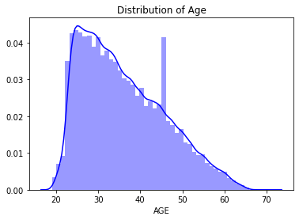

```python
sns.distplot(dd1['AGE'], color = 'blue')
plt.title('Distribution of Age')
```

### **ACTION:**

- ### Now we can safely delete DATE_OF_BIRTH and DISBURSALDATE, therefore will be deleted later

## Updated total no. of columns ond the Data Type.dd1.columns

```python
dd1['DATE_OF_BIRTH'].dtypes
```

```
dtype('<M8[ns]')
```

```python
dd1.info()
```

```
<class 'pandas.core.frame.DataFrame'>
RangeIndex: 233154 entries, 0 to 233153
Data columns (total 43 columns):
 #   Column                               Non-Null Count   Dtype
---  ------                               --------------   -----
 0   UNIQUEID                             233154 non-null  int64
 1   DISBURSED_AMOUNT                     233154 non-null  int64
 2   ASSET_COST                           233154 non-null  int64
 3   LTV                                  233154 non-null  float64
 4   BRANCH_ID                            233154 non-null  int64
 5   SUPPLIER_ID                          233154 non-null  int64
 6   MANUFACTURER_ID                      233154 non-null  int64
 7   CURRENT_PINCODE_ID                   233154 non-null  int64
 8   DATE_OF_BIRTH                        233154 non-null  datetime64[ns]
 9   EMPLOYMENT_TYPE                      233154 non-null  object
```

[output cut: 35 more lines]

# 4. SPLITTING THE DATASET INTO TRAIN-TEST (70-30)

```python
df=dd1.copy()
```

```python
y=df['LOAN_DEFAULT']
X=df.drop("LOAN_DEFAULT",axis=1)
```

```python
# from sklearn.model_selection import train_test_split,KFold,cross_val_score
X_train, X_test, y_train, y_test = train_test_split(X, y, test_size=0.30, random_state=42)
```

```python
print("Size of X",X.shape)
print("Size of y",y.shape)
print("Size of X_train",X_train.shape)
print("Size of y_train",y_train.shape)
```

```
Size of X (233154, 42)
Size of y (233154,)
Size of X_train (163207, 42)
Size of y_train (163207,)
```

```python
y_train_plot=pd.DataFrame(y_train,columns=['LOAN_DEFAULT'])
y_test_plot=pd.DataFrame(y_test,columns=['LOAN_DEFAULT'])

defaulters_train=y_train_plot['LOAN_DEFAULT'].sum()
non_defaulters_train=len(y_train_plot)-y_train_plot['LOAN_DEFAULT'].sum()
total_train=len(y_train_plot)

defaulters_test=y_test_plot['LOAN_DEFAULT'].sum()
non_defaulters_test=len(y_test_plot)-y_test_plot['LOAN_DEFAULT'].sum()
total_test=len(y_test_plot)
```

```python
print("\n")
print("X_TRAIN INFO: Total:",total_train)
print("DEFAULTERS:",defaulters_train,"->",round(defaulters_train/total_train,2),"Percent")
print("Non-DEFAULTERS:",non_defaulters_train,"->",round(non_defaulters_train/total_train,2),"%")
print("\n")
print("X_TEST INFO: Total:",total_test)
print("DEFAULTERS:",defaulters_test,"->",round(defaulters_test/total_test,2),"Percent")
print("Non-DEFAULTERS:",non_defaulters_test,"->",round(non_defaulters_test/total_test,2),"%")
```

```
X_TRAIN INFO: Total: 163207
DEFAULTERS: 35420 -> 0.22 Percent
Non-DEFAULTERS: 127787 -> 0.78 %


X_TEST INFO: Total: 69947
DEFAULTERS: 15191 -> 0.22 Percent
Non-DEFAULTERS: 54756 -> 0.78 %
```

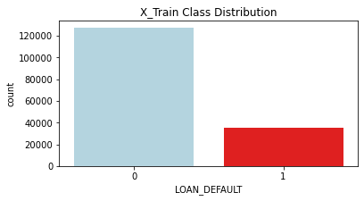

```python
#Graph
my_pal = {0: 'lightblue', 1: 'red'}

plt.figure(figsize = (6, 3))
ax = sns.countplot(x = 'LOAN_DEFAULT', data = y_train_plot, palette = my_pal)
plt.title('X_Train Class Distribution')
plt.show()
```

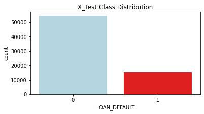

```python
#Graph
my_pal = {0: 'lightblue', 1: 'red'}

plt.figure(figsize = (6, 3))
ax = sns.countplot(x = 'LOAN_DEFAULT', data = y_test_plot, palette = my_pal)
plt.title('X_Test Class Distribution')
plt.show()
```

# 5. FEATURE SELECTION

## -> 5.1. Identifying Useless Features

1. UNIQUEID = It is provided to every customer so its Unique and will always be different.</br>
2. MOBILENO_AVL_FLAG = Whether person provided Mobile No. Doesn't tell us if loan will default.</br>
3. CURRENT_PINCODE_ID = It is Customers address we don't need that for Prediction.</br>
4. EMPLOYEE_CODE_ID = Employee ID is not required as it doesn't related with Loan_defualt.</br>
5. NO_OF_INQUIRIES = No. of Inquiries to loan doesn't help us to determine wheather loan will default or not.</br>
6. STATE_ID = It is where loan is availed and doesn't add much to prediction to loan default.</br>
7. BRANCH_ID = Branch ID isn't relevent to Data Processing.</br>
8. MANUFACTURER_ID = Manufacturer ID doesn't add much too data.</br>
9. SUPPLIER_ID = Supplier ID doesn't add much too data.</br>
10. DATE_OF_BIRTH= As we have calculate the AGE we dont need the Date of Birth.</br>
11. DISBURSALDATE= As we have calculate the LOAN_AGE we dont need the Disbursal Date.</br>

```python
columnsToDelete = ['UNIQUEID','MOBILENO_AVL_FLAG','CURRENT_PINCODE_ID',
                   'EMPLOYEE_CODE_ID','STATE_ID','BRANCH_ID','MANUFACTURER_ID',
                   'SUPPLIER_ID','DATE_OF_BIRTH','DISBURSALDATE','NO_OF_INQUIRIES']
```

### Dropping the useless features.

```python
## BEFORE DELETING THE COLUMNS
print("Size AFTER Deleting the Features",len(X_train.columns))

## DROPING THE COLUMNS FROM THE DATA FRAME
X_train=X_train.drop(X_train[columnsToDelete],axis=1)

## AFTER DROPPING THE COLUMNS
print("Size AFTER Deleting the Features",len(X_train.columns))
```

```
Size AFTER Deleting the Features 42
Size AFTER Deleting the Features 31
```

```python
X_train.columns
```

```
Index(['DISBURSED_AMOUNT', 'ASSET_COST', 'LTV', 'EMPLOYMENT_TYPE',
       'AADHAR_FLAG', 'PAN_FLAG', 'VOTERID_FLAG', 'DRIVING_FLAG',
       'PASSPORT_FLAG', 'PERFORM_CNS_SCORE', 'PERFORM_CNS_SCORE_DESCRIPTION',
       'PRI_NO_OF_ACCTS', 'PRI_ACTIVE_ACCTS', 'PRI_OVERDUE_ACCTS',
       'PRI_CURRENT_BALANCE', 'PRI_SANCTIONED_AMOUNT', 'PRI_DISBURSED_AMOUNT',
       'SEC_NO_OF_ACCTS', 'SEC_ACTIVE_ACCTS', 'SEC_OVERDUE_ACCTS',
       'SEC_CURRENT_BALANCE', 'SEC_SANCTIONED_AMOUNT', 'SEC_DISBURSED_AMOUNT',
       'PRIMARY_INSTAL_AMT', 'SEC_INSTAL_AMT', 'NEW_ACCTS_IN_LAST_SIX_MONTHS',
       'DELINQUENT_ACCTS_IN_LAST_SIX_MONTHS', 'AVERAGE_ACCT_AGE',
       'CREDIT_HISTORY_LENGTH', 'AGE', 'LOAN_AGE'],
      dtype='object')
```

## -> 5.2. Listing the Numerical and Categorical Type Features.

```python
numericalTypes=['DISBURSED_AMOUNT', 'ASSET_COST', 'PRI_NO_OF_ACCTS', 'PRI_ACTIVE_ACCTS', 'LTV',
           'PRI_OVERDUE_ACCTS', 'PRI_CURRENT_BALANCE', 'PRI_SANCTIONED_AMOUNT',
           'PRI_DISBURSED_AMOUNT', 'SEC_NO_OF_ACCTS', 'SEC_ACTIVE_ACCTS', 'SEC_OVERDUE_ACCTS',
           'SEC_CURRENT_BALANCE', 'SEC_SANCTIONED_AMOUNT', 'SEC_DISBURSED_AMOUNT',
           'PRIMARY_INSTAL_AMT', 'SEC_INSTAL_AMT', 'NEW_ACCTS_IN_LAST_SIX_MONTHS', 'PERFORM_CNS_SCORE',
           'DELINQUENT_ACCTS_IN_LAST_SIX_MONTHS', 'LOAN_AGE','AGE','AVERAGE_ACCT_AGE','CREDIT_HISTORY_LENGTH']

categoricalTypes=[ 'AADHAR_FLAG', 'PAN_FLAG', 'VOTERID_FLAG',
             'DRIVING_FLAG', 'PASSPORT_FLAG','EMPLOYMENT_TYPE','PERFORM_CNS_SCORE_DESCRIPTION']
```

```python
len(numericalTypes)
```

```
24
```

```python
len(categoricalTypes)
```

```
7
```

```python
## Creating New dataframe for Numerical and Categorical
X_train_numerical=X_train[numericalTypes].copy()
X_test_numerical=X_test[numericalTypes].copy()
```

# 6. SELECTING THE TOP NUMERICAL FEATURES

## We'll use SelectKBest library to narrow down choices of features. This will make use of Annova test.

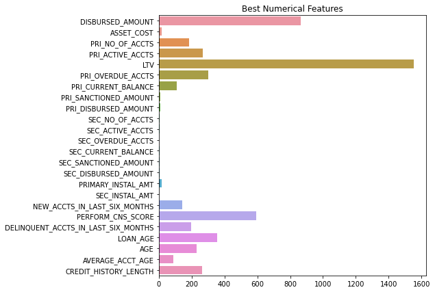

```python
n = SelectKBest(score_func=f_classif,k=16)
# numcols=n.fit(dd11[numericalTypes],dd11['LOAN_DEFAULT'])
numcols=n.fit(X_train_numerical,y_train)
plt.figure(figsize=(7,7))
sns.barplot(x=numcols.scores_,y=numericalTypes)
plt.title('Best Numerical Features')
plt.show()
```

### **OBSERVATION:**

- ### The graph shows that Secondary Account informations are insignificant. But banks can't afford to drop Secondary Account informations. ### **ACTION:**
- ### We will combine the Primary and Secondary Account informations.

```python
## Creating dictionaries to store the feature names and its importance value
topNumFeatures={}

## https://machinelearningmastery.com/feature-selection-with-categorical-data/
for i in range(len(n.scores_)):
    topNumFeatures[numericalTypes[i]]=n.scores_[i]

# SORT THE DICTIONARY AS PER THE IMPORTANT SCORES
topNumFeatures = sorted(topNumFeatures.items(), key=lambda x: x[1],reverse=True)
print("-----------------------TOP FEATURES SORTED AS PER THE HIGH IMPORTANCE----------------")
topNumFeatures
```

```
-----------------------TOP FEATURES SORTED AS PER THE HIGH IMPORTANCE----------------
```

```
[('LTV', 1550.585501137707),
 ('DISBURSED_AMOUNT', 863.1517269795247),
 ('PERFORM_CNS_SCORE', 592.4396877417527),
 ('LOAN_AGE', 353.9901409592188),
 ('PRI_OVERDUE_ACCTS', 303.418914901505),
 ('PRI_ACTIVE_ACCTS', 269.9805998563447),
 ('CREDIT_HISTORY_LENGTH', 263.8419374463975),
 ('AGE', 232.9745581446022),
 ('DELINQUENT_ACCTS_IN_LAST_SIX_MONTHS', 196.59119428463814),
 ('PRI_NO_OF_ACCTS', 187.15344185378814),
 ('NEW_ACCTS_IN_LAST_SIX_MONTHS', 142.81583194446142),
 ('PRI_CURRENT_BALANCE', 108.26241359280226),
 ('AVERAGE_ACCT_AGE', 87.55576365960778),
 ('ASSET_COST', 18.925304124945043),
 ('PRIMARY_INSTAL_AMT', 17.60327544288311),
 ('PRI_SANCTIONED_AMOUNT', 9.481264160694385),
 ('PRI_DISBURSED_AMOUNT', 9.063542106703114),
 ('SEC_NO_OF_ACCTS', 8.015915834127146),
 ('SEC_SANCTIONED_AMOUNT', 6.137398095563498),
 ('SEC_DISBURSED_AMOUNT', 5.962968052085749),
 ('SEC_CURRENT_BALANCE', 4.673842684589463),
 ('SEC_ACTIVE_ACCTS', 4.069622847418212),
 ('SEC_INSTAL_AMT', 0.16302967238609595),
 ('SEC_OVERDUE_ACCTS', 0.1342148080490516)]
```

### Combining the Primary and Secondry information

```python
X_train_numerical.loc[:,'No_of_Accounts'] = X_train_numerical['PRI_NO_OF_ACCTS'] + X_train_numerical['SEC_NO_OF_ACCTS']
X_train_numerical.loc[:,'PRI_Inactive_accounts'] = X_train_numerical['PRI_NO_OF_ACCTS'] - X_train_numerical['PRI_ACTIVE_ACCTS']
X_train_numerical.loc[:,'SEC_Inactive_accounts'] = X_train_numerical['SEC_NO_OF_ACCTS'] - X_train_numerical['SEC_ACTIVE_ACCTS']
X_train_numerical.loc[:,'Total_Inactive_accounts'] = X_train_numerical['PRI_Inactive_accounts'] + X_train_numerical['SEC_Inactive_accounts']
X_train_numerical.loc[:,'Total_Overdue_Accounts'] = X_train_numerical['PRI_OVERDUE_ACCTS'] + X_train_numerical['SEC_OVERDUE_ACCTS']
X_train_numerical.loc[:,'Total_Current_Balance'] = X_train_numerical['PRI_CURRENT_BALANCE'] + X_train_numerical['SEC_CURRENT_BALANCE']
X_train_numerical.loc[:,'Total_Sanctioned_Amount'] = X_train_numerical['PRI_SANCTIONED_AMOUNT'] + X_train_numerical['SEC_SANCTIONED_AMOUNT']
X_train_numerical.loc[:,'Total_Disbursed_Amount'] = X_train_numerical['PRI_DISBURSED_AMOUNT'] + X_train_numerical['SEC_DISBURSED_AMOUNT']
X_train_numerical.loc[:,'Total_Installment'] = X_train_numerical['PRIMARY_INSTAL_AMT'] + X_train_numerical['SEC_INSTAL_AMT']



X_test_numerical.loc[:,'No_of_Accounts'] = X_test_numerical['PRI_NO_OF_ACCTS'] + X_test_numerical['SEC_NO_OF_ACCTS']
X_test_numerical.loc[:,'PRI_Inactive_accounts'] = X_test_numerical['PRI_NO_OF_ACCTS'] - X_test_numerical['PRI_ACTIVE_ACCTS']
X_test_numerical.loc[:,'SEC_Inactive_accounts'] = X_test_numerical['SEC_NO_OF_ACCTS'] - X_test_numerical['SEC_ACTIVE_ACCTS']
X_test_numerical.loc[:,'Total_Inactive_accounts'] = X_test_numerical['PRI_Inactive_accounts'] + X_test_numerical['SEC_Inactive_accounts']
X_test_numerical.loc[:,'Total_Overdue_Accounts'] = X_test_numerical['PRI_OVERDUE_ACCTS'] + X_test_numerical['SEC_OVERDUE_ACCTS']
X_test_numerical.loc[:,'Total_Current_Balance'] = X_test_numerical['PRI_CURRENT_BALANCE'] + X_test_numerical['SEC_CURRENT_BALANCE']
X_test_numerical.loc[:,'Total_Sanctioned_Amount'] = X_test_numerical['PRI_SANCTIONED_AMOUNT'] + X_test_numerical['SEC_SANCTIONED_AMOUNT']
X_test_numerical.loc[:,'Total_Disbursed_Amount'] = X_test_numerical['PRI_DISBURSED_AMOUNT'] + X_test_numerical['SEC_DISBURSED_AMOUNT']
X_test_numerical.loc[:,'Total_Installment'] = X_test_numerical['PRIMARY_INSTAL_AMT'] + X_test_numerical['SEC_INSTAL_AMT']
```

```python
X_test_numerical.columns
```

```
Index(['DISBURSED_AMOUNT', 'ASSET_COST', 'PRI_NO_OF_ACCTS', 'PRI_ACTIVE_ACCTS',
       'LTV', 'PRI_OVERDUE_ACCTS', 'PRI_CURRENT_BALANCE',
       'PRI_SANCTIONED_AMOUNT', 'PRI_DISBURSED_AMOUNT', 'SEC_NO_OF_ACCTS',
       'SEC_ACTIVE_ACCTS', 'SEC_OVERDUE_ACCTS', 'SEC_CURRENT_BALANCE',
       'SEC_SANCTIONED_AMOUNT', 'SEC_DISBURSED_AMOUNT', 'PRIMARY_INSTAL_AMT',
       'SEC_INSTAL_AMT', 'NEW_ACCTS_IN_LAST_SIX_MONTHS', 'PERFORM_CNS_SCORE',
       'DELINQUENT_ACCTS_IN_LAST_SIX_MONTHS', 'LOAN_AGE', 'AGE',
       'AVERAGE_ACCT_AGE', 'CREDIT_HISTORY_LENGTH', 'No_of_Accounts',
       'PRI_Inactive_accounts', 'SEC_Inactive_accounts',
       'Total_Inactive_accounts', 'Total_Overdue_Accounts',
       'Total_Current_Balance', 'Total_Sanctioned_Amount',
       'Total_Disbursed_Amount', 'Total_Installment'],
      dtype='object')
```

```python
X_train_numerical.columns
```

```
Index(['DISBURSED_AMOUNT', 'ASSET_COST', 'PRI_NO_OF_ACCTS', 'PRI_ACTIVE_ACCTS',
       'LTV', 'PRI_OVERDUE_ACCTS', 'PRI_CURRENT_BALANCE',
       'PRI_SANCTIONED_AMOUNT', 'PRI_DISBURSED_AMOUNT', 'SEC_NO_OF_ACCTS',
       'SEC_ACTIVE_ACCTS', 'SEC_OVERDUE_ACCTS', 'SEC_CURRENT_BALANCE',
       'SEC_SANCTIONED_AMOUNT', 'SEC_DISBURSED_AMOUNT', 'PRIMARY_INSTAL_AMT',
       'SEC_INSTAL_AMT', 'NEW_ACCTS_IN_LAST_SIX_MONTHS', 'PERFORM_CNS_SCORE',
       'DELINQUENT_ACCTS_IN_LAST_SIX_MONTHS', 'LOAN_AGE', 'AGE',
       'AVERAGE_ACCT_AGE', 'CREDIT_HISTORY_LENGTH', 'No_of_Accounts',
       'PRI_Inactive_accounts', 'SEC_Inactive_accounts',
       'Total_Inactive_accounts', 'Total_Overdue_Accounts',
       'Total_Current_Balance', 'Total_Sanctioned_Amount',
       'Total_Disbursed_Amount', 'Total_Installment'],
      dtype='object')
```

```python
print("Shape of X_train_numerical: ",X_train_numerical.shape)
print("Shape of X_test_numerical: ",X_test_numerical.shape)
```

```
Shape of X_train_numerical:  (163207, 33)
Shape of X_test_numerical:  (69947, 33)
```

## Now dropping the unwanted columns as we have already merged them

```python
X_train_numerical=X_train_numerical.drop(['PRI_NO_OF_ACCTS','SEC_NO_OF_ACCTS',
			'PRI_ACTIVE_ACCTS','SEC_ACTIVE_ACCTS',
			'PRI_CURRENT_BALANCE','SEC_CURRENT_BALANCE',
			'PRI_Inactive_accounts','SEC_Inactive_accounts',
            'PRI_SANCTIONED_AMOUNT','SEC_SANCTIONED_AMOUNT',
            'PRI_DISBURSED_AMOUNT','SEC_DISBURSED_AMOUNT',
            'PRI_OVERDUE_ACCTS','SEC_OVERDUE_ACCTS',
            'PRIMARY_INSTAL_AMT','SEC_INSTAL_AMT'],axis=1)

X_test_numerical=X_test_numerical.drop(['PRI_NO_OF_ACCTS','SEC_NO_OF_ACCTS',
			'PRI_ACTIVE_ACCTS','SEC_ACTIVE_ACCTS',
			'PRI_CURRENT_BALANCE','SEC_CURRENT_BALANCE',
			'PRI_Inactive_accounts','SEC_Inactive_accounts',
            'PRI_SANCTIONED_AMOUNT','SEC_SANCTIONED_AMOUNT',
            'PRI_DISBURSED_AMOUNT','SEC_DISBURSED_AMOUNT',
            'PRI_OVERDUE_ACCTS','SEC_OVERDUE_ACCTS',
            'PRIMARY_INSTAL_AMT','SEC_INSTAL_AMT'],axis=1)
```

```python
X_test_numerical.columns
```

```
Index(['DISBURSED_AMOUNT', 'ASSET_COST', 'LTV', 'NEW_ACCTS_IN_LAST_SIX_MONTHS',
       'PERFORM_CNS_SCORE', 'DELINQUENT_ACCTS_IN_LAST_SIX_MONTHS', 'LOAN_AGE',
       'AGE', 'AVERAGE_ACCT_AGE', 'CREDIT_HISTORY_LENGTH', 'No_of_Accounts',
       'Total_Inactive_accounts', 'Total_Overdue_Accounts',
       'Total_Current_Balance', 'Total_Sanctioned_Amount',
       'Total_Disbursed_Amount', 'Total_Installment'],
      dtype='object')
```

```python
X_train_numerical.columns
```

```
Index(['DISBURSED_AMOUNT', 'ASSET_COST', 'LTV', 'NEW_ACCTS_IN_LAST_SIX_MONTHS',
       'PERFORM_CNS_SCORE', 'DELINQUENT_ACCTS_IN_LAST_SIX_MONTHS', 'LOAN_AGE',
       'AGE', 'AVERAGE_ACCT_AGE', 'CREDIT_HISTORY_LENGTH', 'No_of_Accounts',
       'Total_Inactive_accounts', 'Total_Overdue_Accounts',
       'Total_Current_Balance', 'Total_Sanctioned_Amount',
       'Total_Disbursed_Amount', 'Total_Installment'],
      dtype='object')
```

```python
print("After Droping: Shape of X_train_numerical: ",X_train_numerical.shape)
print("After Droping: Shape of X_test_numerical: ",X_test_numerical.shape)
```

```
After Droping: Shape of X_train_numerical:  (163207, 17)
After Droping: Shape of X_test_numerical:  (69947, 17)
```

### Now we update our Numerical Feature List with the newly added Features

```python
numericalTypesUpdated=['DISBURSED_AMOUNT', 'ASSET_COST', 'LTV', 'NEW_ACCTS_IN_LAST_SIX_MONTHS',
           'PERFORM_CNS_SCORE','DELINQUENT_ACCTS_IN_LAST_SIX_MONTHS', 'LOAN_AGE','AGE',
           'AVERAGE_ACCT_AGE','CREDIT_HISTORY_LENGTH',
           'No_of_Accounts', 'Total_Inactive_accounts','Total_Overdue_Accounts',
           'Total_Current_Balance','Total_Sanctioned_Amount', 'Total_Disbursed_Amount','Total_Installment']
```

# 7. STANDARDIZING THE TRAIN AND TEST DATA

```python
## Before Standardization
X_train.head()
```

|  | DISBURSED_AMOUNT | ASSET_COST | LTV | EMPLOYMENT_TYPE | AADHAR_FLAG | PAN_FLAG | VOTERID_FLAG | DRIVING_FLAG | PASSPORT_FLAG | PERFORM_CNS_SCORE | ... | SEC_SANCTIONED_AMOUNT | SEC_DISBURSED_AMOUNT | PRIMARY_INSTAL_AMT | SEC_INSTAL_AMT | NEW_ACCTS_IN_LAST_SIX_MONTHS | DELINQUENT_ACCTS_IN_LAST_SIX_MONTHS | AVERAGE_ACCT_AGE | CREDIT_HISTORY_LENGTH | AGE | LOAN_AGE |
| --- | --- | --- | --- | --- | --- | --- | --- | --- | --- | --- | --- | --- | --- | --- | --- | --- | --- | --- | --- | --- | --- |
| 81759 | 56013 | 67722 | 85.64 | Self employed | 1 | 0 | 0 | 0 | 0 | 738 | ... | 0 | 0 | 0 | 0 | 1 | 0 | 0.333333 | 0.333333 | 41.0 | 2.0 |
| 115977 | 53278 | 68455 | 79.76 | Self employed | 1 | 0 | 0 | 0 | 0 | 694 | ... | 0 | 0 | 1932 | 0 | 0 | 0 | 0.583333 | 0.583333 | 25.0 | 1.0 |
| 51043 | 27929 | 62459 | 48.03 | Salaried | 1 | 0 | 0 | 0 | 0 | 0 | ... | 0 | 0 | 0 | 0 | 0 | 0 | 0.000000 | 0.000000 | 41.0 | 2.0 |
| 18380 | 35275 | 64929 | 56.99 | Self employed | 1 | 0 | 0 | 0 | 0 | 690 | ... | 0 | 0 | 0 | 0 | 2 | 0 | 1.333333 | 3.083333 | 57.0 | 2.0 |
| 192570 | 67582 | 81193 | 84.98 | Self employed | 1 | 0 | 0 | 0 | 0 | 681 | ... | 0 | 0 | 3360 | 0 | 0 | 1 | 0.833333 | 0.916667 | 20.0 | 1.0 |

5 rows × 31 columns

```python
scaler = StandardScaler()
scaler.fit(X_train_numerical)
X_train_numerical_std = scaler.transform(X_train_numerical)
X_test_numerical_std = scaler.transform(X_test_numerical)
```

```python
## Type of Returned Data
type(X_train_numerical_std)
```

```
numpy.ndarray
```

```python
X_train_numerical_std
```

```
array([[ 0.12597068, -0.42587753,  0.95032085, ..., -0.07753104,
        -0.07722877, -0.08735027],
       [-0.08282314, -0.38748117,  0.43681283, ..., -0.05807032,
        -0.0577724 , -0.07493134],
       [-2.01800212, -0.70156649, -2.33420921, ..., -0.08286073,
        -0.08255726, -0.08735027],
       ...,
       [-0.80264651, -0.77799252, -0.01468998, ..., -0.08286073,
        -0.08255726, -0.08735027],
       [-0.27176819, -0.36338524, -0.00246359, ..., -0.08286073,
        -0.08255726, -0.07835747],
       [-0.57362221, -0.04463788, -0.88101644, ..., -0.08286073,
        -0.08255726, -0.07700759]])
```

### Converting the ndarray to Pandas DataFrame with Column Names

```python
X_train_numerical_std=pd.DataFrame(X_train_numerical_std,columns=['DISBURSED_AMOUNT', 'ASSET_COST', 'LTV', 'NEW_ACCTS_IN_LAST_SIX_MONTHS',
       'PERFORM_CNS_SCORE', 'DELINQUENT_ACCTS_IN_LAST_SIX_MONTHS', 'LOAN_AGE',
       'AGE', 'AVERAGE_ACCT_AGE', 'CREDIT_HISTORY_LENGTH', 'No_of_Accounts',
       'Total_Inactive_accounts', 'Total_Overdue_Accounts',
       'Total_Current_Balance', 'Total_Sanctioned_Amount',
       'Total_Disbursed_Amount', 'Total_Installment'])

X_test_numerical_std=pd.DataFrame(X_test_numerical_std,columns=['DISBURSED_AMOUNT', 'ASSET_COST', 'LTV', 'NEW_ACCTS_IN_LAST_SIX_MONTHS',
       'PERFORM_CNS_SCORE', 'DELINQUENT_ACCTS_IN_LAST_SIX_MONTHS', 'LOAN_AGE',
       'AGE', 'AVERAGE_ACCT_AGE', 'CREDIT_HISTORY_LENGTH', 'No_of_Accounts',
       'Total_Inactive_accounts', 'Total_Overdue_Accounts',
       'Total_Current_Balance', 'Total_Sanctioned_Amount',
       'Total_Disbursed_Amount', 'Total_Installment'])
```

```python
# Checking the values after converting
X_train_numerical_std
```

|  | DISBURSED_AMOUNT | ASSET_COST | LTV | NEW_ACCTS_IN_LAST_SIX_MONTHS | PERFORM_CNS_SCORE | DELINQUENT_ACCTS_IN_LAST_SIX_MONTHS | LOAN_AGE | AGE | AVERAGE_ACCT_AGE | CREDIT_HISTORY_LENGTH | No_of_Accounts | Total_Inactive_accounts | Total_Overdue_Accounts | Total_Current_Balance | Total_Sanctioned_Amount | Total_Disbursed_Amount | Total_Installment |
| --- | --- | --- | --- | --- | --- | --- | --- | --- | --- | --- | --- | --- | --- | --- | --- | --- | --- |
| 0 | 0.125971 | -0.425878 | 0.950321 | 0.642394 | 1.324570 | -0.252379 | 0.614378 | 0.514217 | -0.324522 | -0.428112 | -0.280741 | -0.350434 | -0.286717 | -0.174807 | -0.077531 | -0.077229 | -0.087350 |
| 1 | -0.082823 | -0.387481 | 0.436813 | -0.398491 | 1.194620 | -0.252379 | -1.627663 | -1.118980 | -0.126253 | -0.322965 | -0.093926 | -0.106370 | -0.286717 | -0.109253 | -0.058070 | -0.057772 | -0.074931 |
| 2 | -2.018002 | -0.701566 | -2.334209 | -0.398491 | -0.855044 | -0.252379 | 0.614378 | 0.514217 | -0.588880 | -0.568307 | -0.467555 | -0.350434 | -0.286717 | -0.181252 | -0.082861 | -0.082557 | -0.087350 |
| 3 | -1.457198 | -0.572182 | -1.551721 | 1.683279 | 1.182806 | -0.252379 | 0.614378 | 2.147414 | 0.468554 | 0.728502 | 1.400590 | 1.602079 | -0.286717 | -0.158054 | -0.069265 | -0.069267 | -0.087350 |
| 4 | 1.009165 | 0.279767 | 0.892682 | -0.398491 | 1.156226 | 2.329579 | -1.627663 | -1.629353 | 0.072016 | -0.182769 | -0.093926 | -0.106370 | -0.286717 | -0.159429 | -0.071834 | -0.071533 | -0.065752 |
| ... | ... | ... | ... | ... | ... | ... | ... | ... | ... | ... | ... | ... | ... | ... | ... | ... | ... |
| 163202 | -1.647364 | -1.814013 | 0.886569 | -0.398491 | -0.855044 | -0.252379 | 0.614378 | -0.710680 | -0.588880 | -0.568307 | -0.467555 | -0.350434 | -0.286717 | -0.181252 | -0.082861 | -0.082557 | -0.087350 |
| 163203 | 3.124662 | 3.518889 | -0.434754 | -0.398491 | -0.855044 | -0.252379 | 0.614378 | -1.221054 | -0.588880 | -0.568307 | -0.467555 | -0.350434 | -0.286717 | -0.181252 | -0.082861 | -0.082557 | -0.087350 |
| 163204 | -0.802647 | -0.777993 | -0.014690 | -0.398491 | -0.855044 | -0.252379 | 0.614378 | -0.404456 | -0.588880 | -0.568307 | -0.467555 | -0.350434 | -0.286717 | -0.181252 | -0.082861 | -0.082557 | -0.087350 |
| 163205 | -0.271768 | -0.363385 | -0.002464 | -0.398491 | 1.581516 | -0.252379 | 0.614378 | 0.207993 | -0.192343 | -0.358014 | -0.280741 | -0.106370 | -0.286717 | -0.181252 | -0.082861 | -0.082557 | -0.078357 |
| 163206 | -0.573622 | -0.044638 | -0.881016 | -0.398491 | 1.581516 | -0.252379 | 0.614378 | -0.812755 | -0.060163 | -0.287916 | -0.280741 | -0.106370 | -0.286717 | -0.181252 | -0.082861 | -0.082557 | -0.077008 |

163207 rows × 17 columns

```python
print("Shape of Standardized X_train: ",X_train_numerical_std.shape)
print("Shape of Standardized X_test: ",X_test_numerical_std.shape)
```

```
Shape of Standardized X_train:  (163207, 17)
Shape of Standardized X_test:  (69947, 17)
```

## Reconfirming the K BEST FEATURES after standardization

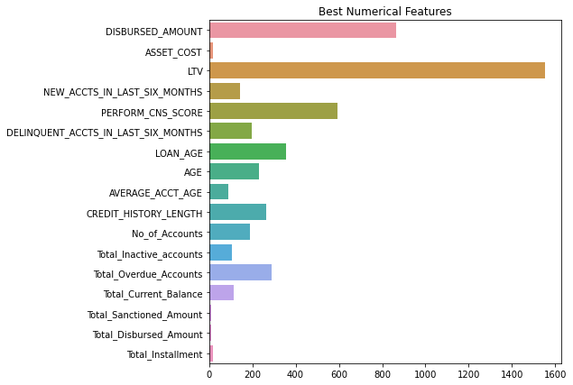

```python
nn = SelectKBest(score_func=f_classif,k='all')
numcols=nn.fit(X_train_numerical_std,y_train)
plt.figure(figsize=(7,7))
sns.barplot(x=numcols.scores_,y=X_train_numerical_std.columns)
plt.title('Best Numerical Features')
plt.show()
```

```python
## Creating dictionaries to store the feature names and its importance value
topNumFeatures={}

## https://machinelearningmastery.com/feature-selection-with-categorical-data/
for i in range(len(nn.scores_)):
#     print('Feature %s: %f' % (numerical[i], n.scores_[i]))
    topNumFeatures[numericalTypesUpdated[i]]=nn.scores_[i]

# SORT THE DICTIONARY AS PER THE IMPORTANT SCORES
topNumFeatures = sorted(topNumFeatures.items(), key=lambda x: x[1],reverse=True)
print("-----------------------TOP FEATURES SORTED AS PER THE HIGH IMPORTANCE----------------")
topNumFeatures
```

```
-----------------------TOP FEATURES SORTED AS PER THE HIGH IMPORTANCE----------------
```

```
[('LTV', 1550.5855011386789),
 ('DISBURSED_AMOUNT', 863.1517269793808),
 ('PERFORM_CNS_SCORE', 592.4396877413718),
 ('LOAN_AGE', 353.9901409593915),
 ('Total_Overdue_Accounts', 288.9355920288955),
 ('CREDIT_HISTORY_LENGTH', 263.84193744638105),
 ('AGE', 232.97455814465795),
 ('DELINQUENT_ACCTS_IN_LAST_SIX_MONTHS', 196.5911942848705),
 ('No_of_Accounts', 191.24014036474725),
 ('NEW_ACCTS_IN_LAST_SIX_MONTHS', 142.81583194445406),
 ('Total_Current_Balance', 112.26023331694557),
 ('Total_Inactive_accounts', 104.3813781424166),
 ('AVERAGE_ACCT_AGE', 87.55576365955291),
 ('ASSET_COST', 18.925304124725937),
 ('Total_Installment', 17.741177619471454),
 ('Total_Sanctioned_Amount', 10.296019203093188),
 ('Total_Disbursed_Amount', 9.846072313550028)]
```